# Tanner’s Analysis

Tanner Dunn

4/22/2021

```r
library(ggplot2)
library(tidyr)
library(dplyr)

main <- readr::read_csv('./excel_files/data.csv')
by_artist <- readr::read_csv('./excel_files/data_by_artist.csv')
by_genre <- readr::read_csv('./excel_files/data_by_genres.csv')
by_year <- readr::read_csv('./excel_files/data_by_year.csv')

main <- drop_na(main)
```

## Final Project Questions

**1.** Does a success of a song depend on the date of the song released?

**2.** Does the popularity of a song depend on the danceability and loudness?

**3.** What were the five most popular songs in 2020? Is there a correlation with popularity and energy?

```r
#not finished
q3 <- main %>%
      filter(year == 2020) %>%
      select(artists, name, popularity, energy) %>%
      arrange(desc(popularity)) %>%
      head(5)
```

**4.** Analyze how song trends (danceability, energy, etc..), changed throughout each year.

```r
q4 <- main %>%
      group_by(year) %>%
      summarise(danceability = mean(danceability),
                acousticness = mean(acousticness),
                energy = mean(energy),
                valence = mean(valence),
                liveness = mean(liveness))

q4
```

```
## # A tibble: 102 x 6
##     year danceability acousticness energy valence liveness
##    <dbl>        <dbl>        <dbl>  <dbl>   <dbl>    <dbl>
##  1  1920        0.516        0.631  0.419   0.498    0.216
##  2  1921        0.432        0.862  0.241   0.378    0.205
##  3  1922        0.576        0.829  0.226   0.571    0.257
##  4  1923        0.577        0.957  0.262   0.625    0.227
##  5  1924        0.550        0.940  0.344   0.664    0.235
##  6  1925        0.575        0.963  0.278   0.621    0.237
##  7  1926        0.597        0.666  0.211   0.437    0.232
##  8  1927        0.656        0.916  0.268   0.670    0.177
##  9  1928        0.535        0.939  0.209   0.497    0.175
## 10  1929        0.648        0.601  0.242   0.637    0.236
## # ... with 92 more rows
```

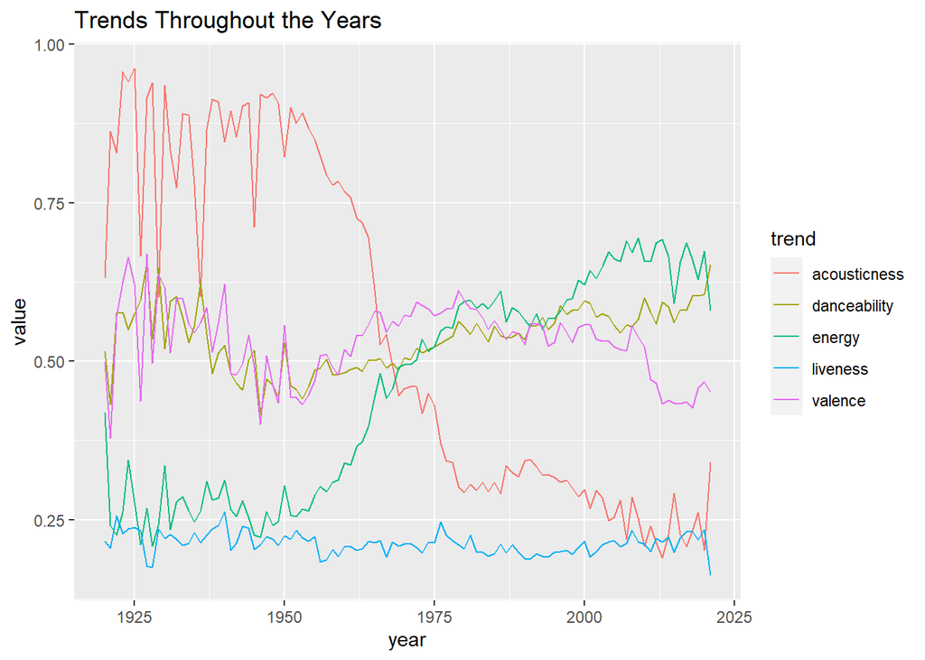

```r
#Plot for song trends
q4 <- q4 %>% pivot_longer(danceability:liveness, names_to = 'trend', values_to = 'value')

q4_plot <- q4 %>%
      ggplot(aes(x = year, y = value, color = trend)) + geom_line() +
      ggtitle("Trends Throughout the Years")

q4_plot
```

**5.** Analyze relationship between temp and acousticness.

**6.** What is the greatest predictor of a song’s popularity?

```r
#This is more of a regression problem which was not covered in this class (Maybe Remove?)
```

**7.** Who are the most popular one hit wonders?

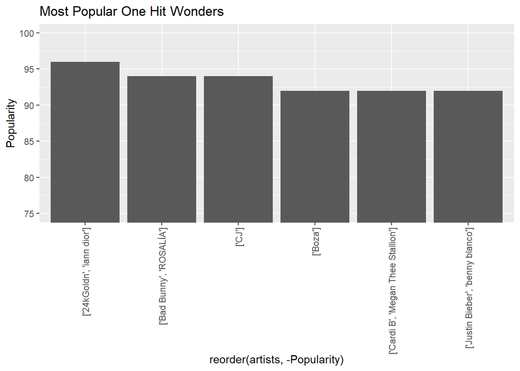

```r
one_hit_wonder <- main %>%
   group_by(artists = artists) %>%
   summarise(Num_track = n(), Popularity = mean(popularity)) %>%
   filter(Num_track == 1) %>%
   top_n(5, wt = Popularity)

   ggplot(one_hit_wonder, aes(x = reorder(artists, -Popularity), weight = Popularity)) + geom_bar() + coord_cartesian(ylim=c(75,100)) + theme(axis.text.x = element_text(angle = 90, hjust = 1, vjust = .5)) + ylab("Popularity") + ggtitle("Most Popular One Hit Wonders")
```

Now that we found the popular one hit wonder artists or groups, lets look at the one song they released

```r
one_hit_names <- inner_join(main, one_hit_wonder, by = 'artists')
summarise(one_hit_names, name, artists)
```

```
## # A tibble: 6 x 2
##   name                            artists
##   <chr>                           <chr>
## 1 Mood (feat. iann dior)          ['24kGoldn', 'iann dior']
## 2 Whoopty                         ['CJ']
## 3 WAP (feat. Megan Thee Stallion) ['Cardi B', 'Megan Thee Stallion']
## 4 Lonely (with benny blanco)      ['Justin Bieber', 'benny blanco']
## 5 LA NOCHE DE ANOCHE              ['Bad Bunny', 'ROSALÍA']
## 6 Hecha Pa' Mi                    ['Boza']
```

**8.** How has Post Malone (My Favorite Artist) Popularity changed over the past few years

```r
dat <- main %>%
   group_by(year = year, artists = artists) %>%
   summarise(popularity = mean(popularity)) %>%
   filter(artists == "['Post Malone']")
```

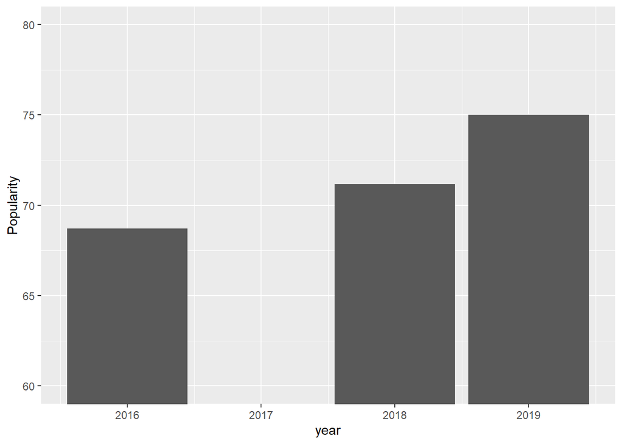

```r
ggplot(dat, aes(x = year, weight = popularity)) + geom_bar() + ylab('Popularity') + coord_cartesian(ylim=c(60, 80))
```

Post Malone has dropped 3 albums, the first in 2016, second in 2018, and the third in 2019, therefore those are the years he has a popularity value. It is clear that he is becoming more and more popular with each album that he releases.